# Analysis of Tweets from @WeRateDogs account

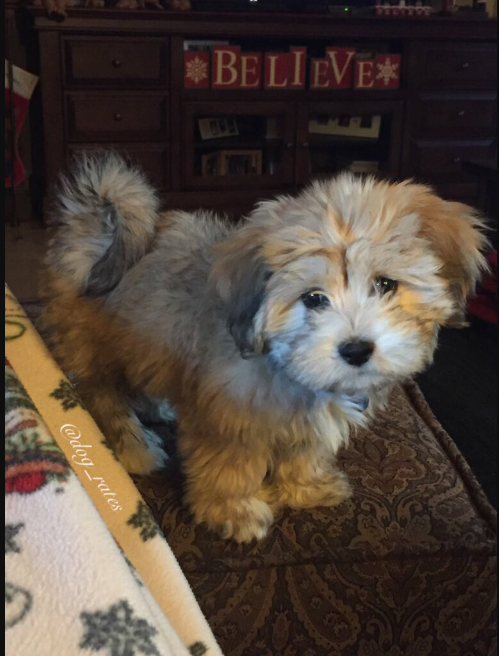

**This Twitter account shares pictures of dogs along with the rating and a description, where the rating denominator is usually 10. However, the numerators are usually greater than 10. We have made some interesting and important visualizations regarding the tweets**

## Analyzing and Visualizing Data

### What is the relationship between Favourite Count and Retweet Count?

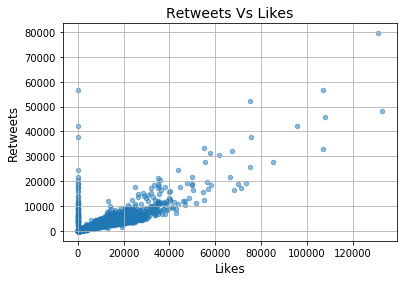

Using a scatterplot, we conclude that the Retweets and Likes are strongly and positively correlated with each other. This means as the Likes of a tweet increases the Retweets also increases simultaneously.

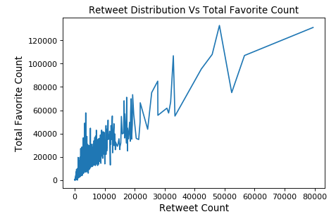

The above graph also shows a linear relationship between Retweets and Favorites Count (i.e Likes). It can be clearly observed seen that as the Favorites Count has increases, the retweets have also increased.

### What are the top 5 most common dog names?

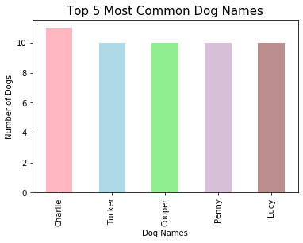

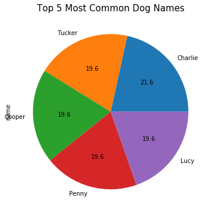

From the above visualizations, the most common dog name in WeRateDogs tweets is **Charlie**, then it is followed by Tucker, Cooper, Penny, and Lucy. From the pie-chart, we also see that the name Charlie was used approximately 21.6% of the time which is the greatest among all other dog names, while the following dogs Tucker, Cooper, Penny, and Lucy all have the same percentages that is 19.6%.

## Conclusion

We can do so much more with this dataset, but for our Nanodegree project this is more than enough.